# Binary effects of sediment on recruitment of juvenile corals

Lillian J. Tuttle

9/24/2020

#### Here I will explore how DEPOSITED AND SUSPENDED sediment affects the RECRUITMENT of tropical, scleractinean coral JUVENILES. The database to be used is comprised of data extracted from studies deemed relevant during the systematic literature review process.

# The Dataset

## Deposited Sediment

Specifically, we will explore the results of 132 datapoints from 3 studies conducted in 1 ocean on 4 species within 2 genera.

```
##     n
## 1 132
```

```
##    Ref   n
## 1 DS13 126
## 2 DS37   4
## 3 DS02   2
```

```
##                   Ref_name   n
## 1    Moeller et al. (2017) 126
## 2  Fabricius et al. (2003)   4
## 3 Babcock and Smith (2000)   2
```

```
##     Ocean   n
## 1 Pacific 132
```

```
##                   Gsp  n
## 1 Leptastrea_purpurea 99
## 2 Acropora_hyacinthus 27
## 3   Acropora_willisae  4
## 4  Acropora_millepora  2
```

```
##   Updated_Genus  n
## 1    Leptastrea 99
## 2      Acropora 33
```

## Suspended Sediment

Specifically, we will explore the results of 16 datapoints from 2 studies conducted in 1 ocean on 4 species within 3 genera.

```
##    n
## 1 16
```

```
##     Ref  n
## 1 SS12a 12
## 2 SS18d  4
```

```
##               Ref_name  n
## 1 Humanes et al. 2017a 12
## 2  Moeller et al. 2017  4
```

```
##     Ocean  n
## 1 Pacific 16
```

```
##                   Gsp n
## 1  Acropora_millepora 4
## 2     Acropora_tenuis 4
## 3 Leptastrea_purpurea 4
## 4   Pocillopora_acuta 4
```

```
##   Updated_Genus n
## 1      Acropora 8
## 2    Leptastrea 4
## 3   Pocillopora 4
```

# Exploratory plots

First let’s explore all data from all species for which there is binary data about the presence of ‘recruit mortality’ as a result of exposure to deposited sediment.

##### DEFINITIONS:

- ‘**Recruit mortality**’ is the death of a juvenile coral, after it has settled to the reef surface, but before it has reached adult size/reproductive status.

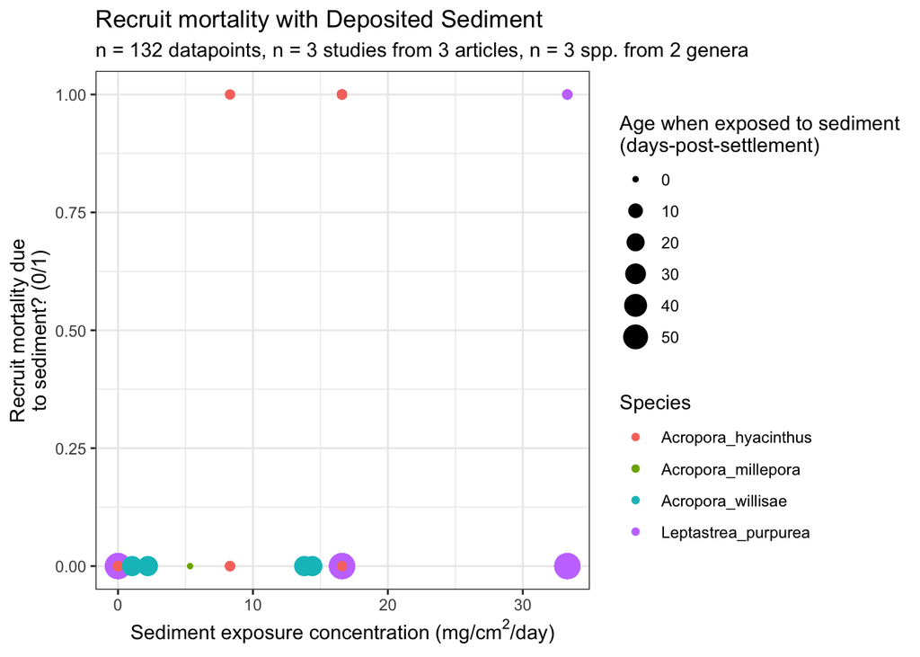

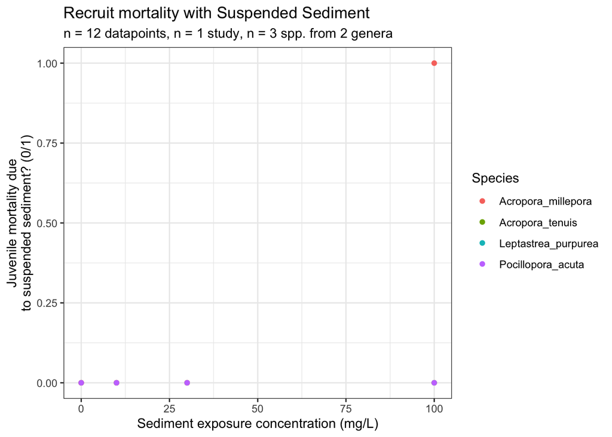

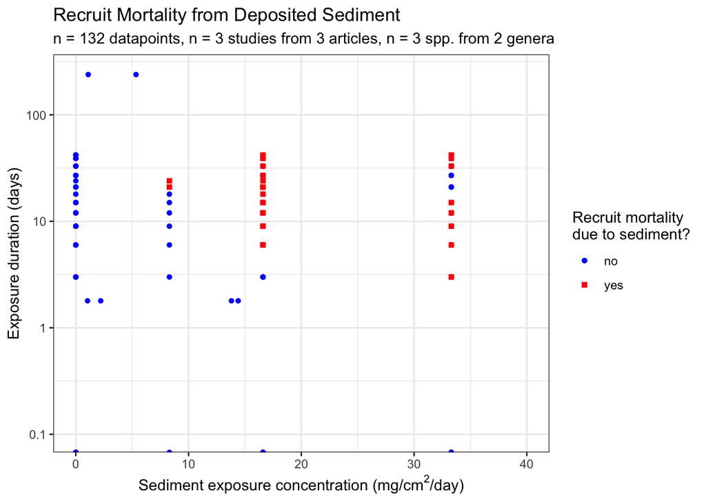

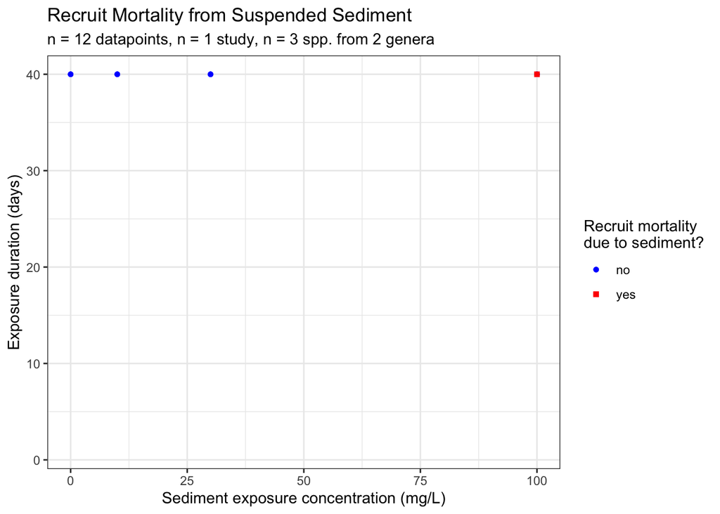

# Threshold Analyses with Binary Data

Now let’s calculate thresholds based on the binary data explored above.

##### DEFINITIONS:

- ‘**LOAEL**’, or the ‘lowest observed adverse effect level’ is defined as the lowest dose at which there was an observed adverse effect.
- ‘**NOAEL**’, or the ‘no observed adverse effect level’ is defined as the highest dose at which there was NOT an observed adverse effect.
- ‘**Adverse effect**’ is defined here as any response of a coral individual, colony, or experimental treatment group that *may* negatively affect the coral’s fitness and/or survival. These adverse effects may include sublethal physiological changes (e.g., significantly reduced growth or photosynthetic rates when compared to coral in ambient/control conditions), bleaching/tissue loss, and mortality. This definition of adverse effect is independent of its magnitude, so while the affect may have potentially reduced fitness, its magnitude may be sufficiently small that the fitness effect is not measureable.

## DEPOSITED SEDIMENT

### NOAEL/LOAEL defined by exposure concentration

```
##   LOAEL
## 1   8.3
```

```
##   NOAEL
## 1   8.3
```

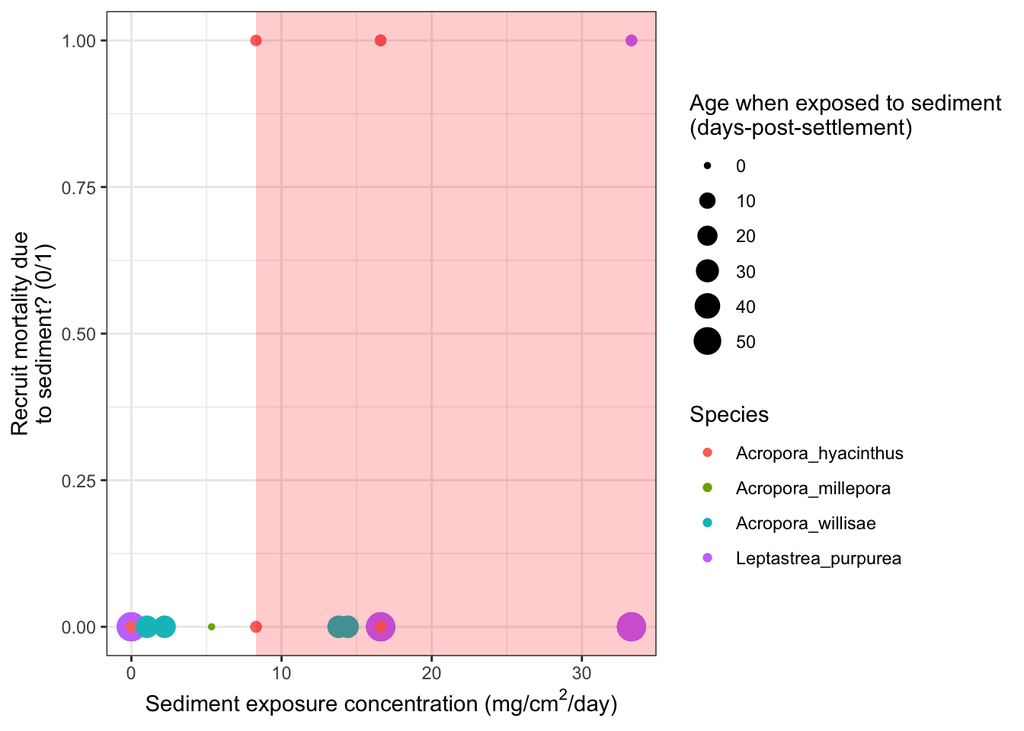

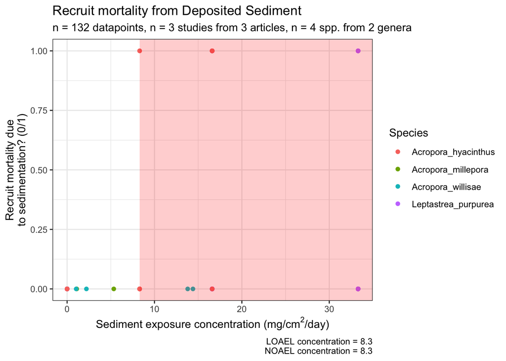

###NOAEL/LOAEL defined by exposure duration

```
##   LOAEL
## 1     3
```

```
##   NOAEL
## 1     3
```

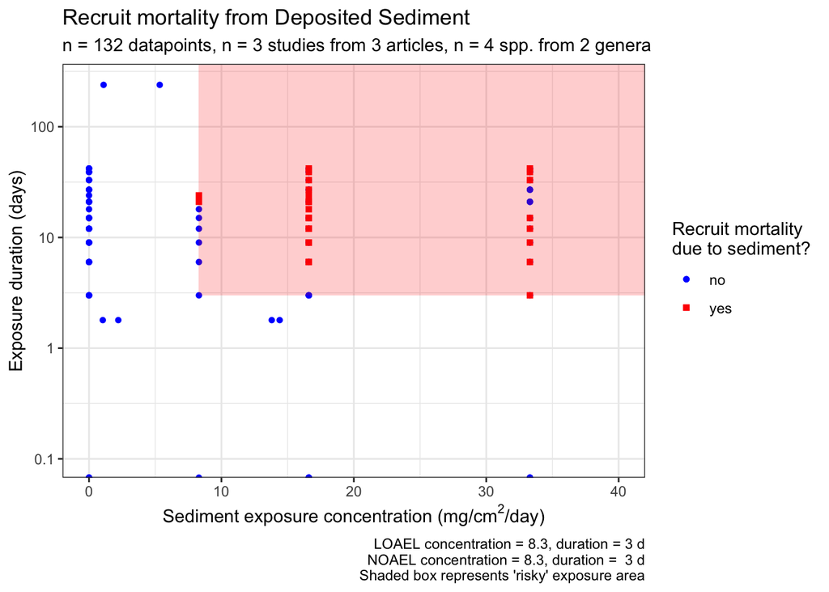

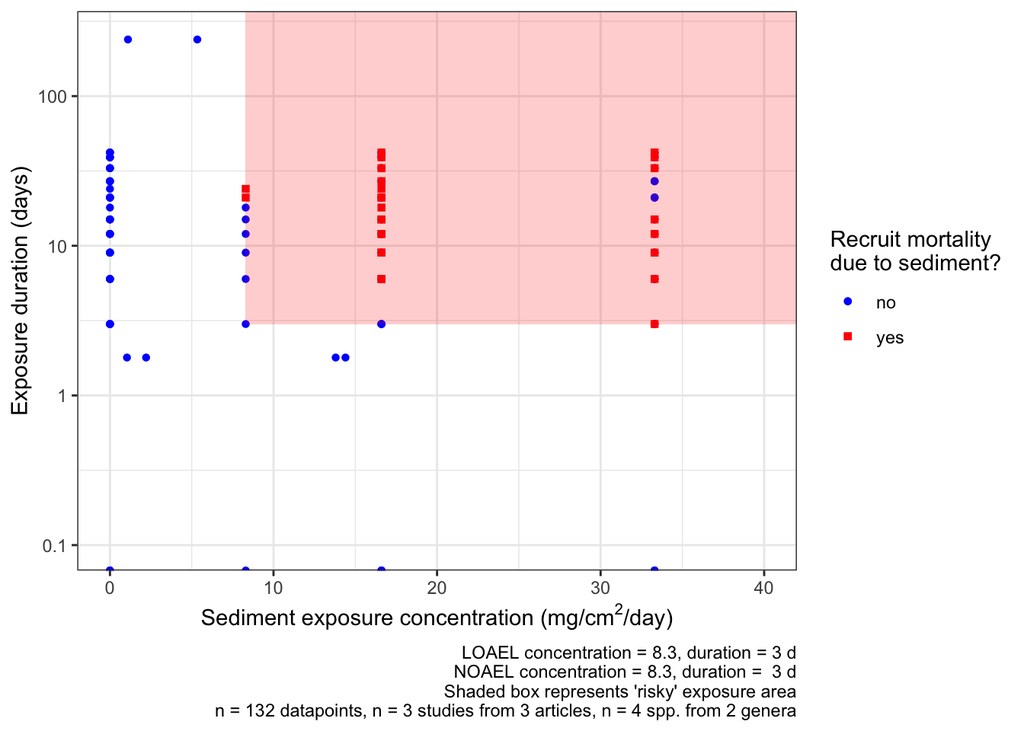

## SUSPENDED SEDIMENT

### NOAEL/LOAEL defined by exposure concentration

```
##   LOAEL
## 1   100
```

```
##   NOAEL
## 1   100
```

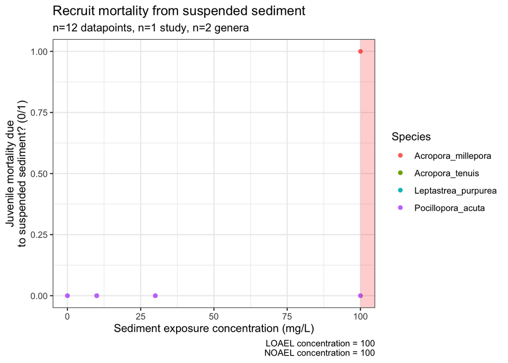

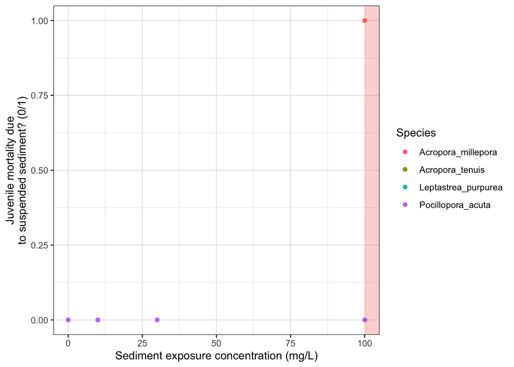

###NOAEL/LOAEL defined by exposure duration

[output not shown]

```
##   NOAEL
## 1    40
```

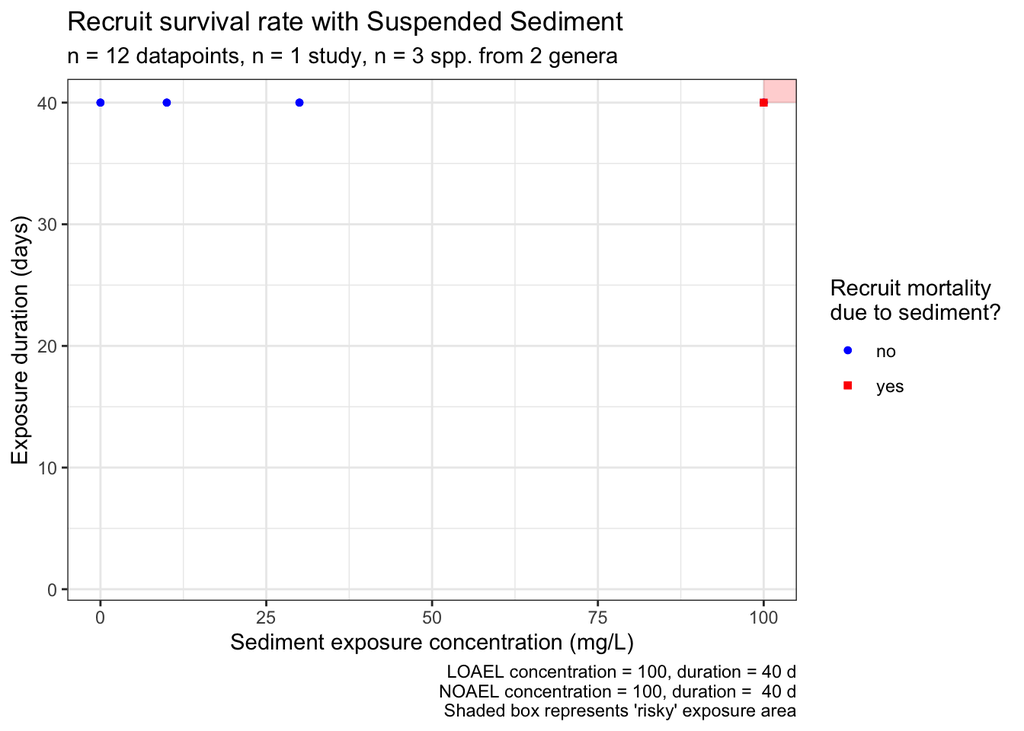

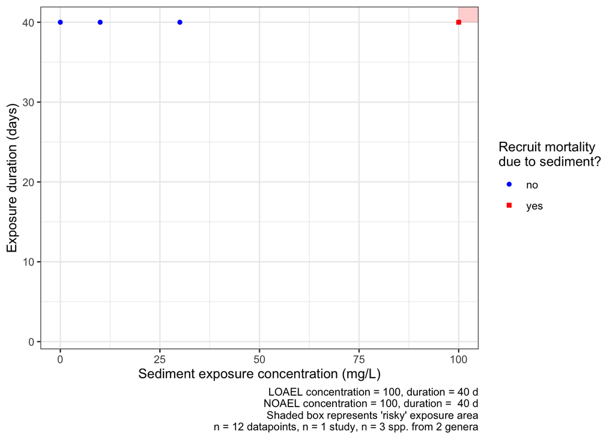

# Logistic Regression Model Fitting

## Deposited Sediment

```
##    n
## 1 87
```

```
##         df       AIC
## modDS1b  3  56.56522
## modDS2b  4  58.49642
## modDS3b  5  57.29443
## modDS1   2 109.85245
## modDS2   3 111.85228
## modDS3   4 113.30297
```

[output not shown]

[output not shown]

```
## Data: recruitDS2
## Models:
## modDS7: Binary_recruit_death ~ Sed_level_stand_mg + Coral_age_at_start_expt_days_since_settled +
## modDS7:     (1 | Ref)
## modDS8: Binary_recruit_death ~ Sed_level_stand_mg + Sed_exposure_days +
## modDS8:     Coral_age_at_start_expt_days_since_settled + (1 | Ref)
## modDS9: Binary_recruit_death ~ Sed_level_stand_mg * Sed_exposure_days +
## modDS9:     Coral_age_at_start_expt_days_since_settled + (1 | Ref)
##        npar    AIC    BIC  logLik deviance  Chisq Df Pr(>Chisq)
## modDS7    4 58.565 68.429 -25.283   50.565
## modDS8    5 60.496 72.826 -25.248   50.496 0.0688  1    0.79309
## modDS9    6 59.294 74.090 -23.647   47.294 3.2020  1    0.07355 .
## ---
## Signif. codes:  0 '***' 0.001 '**' 0.01 '*' 0.05 '.' 0.1 ' ' 1
```

```
## Data: recruitDS2
## Models:
## modDS4: Binary_recruit_death ~ Sed_level_stand_mg + Coral_age_at_start_expt_days_since_settled +
## modDS4:     (1 | Gsp)
## modDS7: Binary_recruit_death ~ Sed_level_stand_mg + Coral_age_at_start_expt_days_since_settled +
## modDS7:     (1 | Ref)
## modDS10: Binary_recruit_death ~ Sed_level_stand_mg + Coral_age_at_start_expt_days_since_settled +
## modDS10:     (1 | Gsp) + (1 | Ref)
##         npar    AIC    BIC  logLik deviance Chisq Df Pr(>Chisq)
## modDS4     4 58.565 68.429 -25.283   50.565
## modDS7     4 58.565 68.429 -25.283   50.565     0  0          1
## modDS10    5 60.565 72.895 -25.283   50.565     0  1          1
```

```
## Generalized linear mixed model fit by maximum likelihood (Laplace
##   Approximation) [glmerMod]
##  Family: binomial  ( logit )
## Formula:
## Binary_recruit_death ~ Sed_level_stand_mg + Coral_age_at_start_expt_days_since_settled +
##     (1 | Ref)
##    Data: recruitDS2
##
##      AIC      BIC   logLik deviance df.resid
##     58.6     68.4    -25.3     50.6       83
##
## Scaled residuals:
##      Min       1Q   Median       3Q      Max
## -2.36131 -0.05331 -0.00090  0.42349  1.11581
##
## Random effects:
##  Groups Name        Variance Std.Dev.
##  Ref    (Intercept) 0        0
## Number of obs: 87, groups:  Ref, 3
##
## Fixed effects:
##                                            Estimate Std. Error z value Pr(>|z|)
## (Intercept)                                -0.27926    0.82786  -0.337    0.736
## Sed_level_stand_mg                          0.07750    0.04168   1.859    0.063
## Coral_age_at_start_expt_days_since_settled -0.29160    0.18880  -1.545    0.122
##
## (Intercept)
## Sed_level_stand_mg                         .
## Coral_age_at_start_expt_days_since_settled
## ---
## Signif. codes:  0 '***' 0.001 '**' 0.01 '*' 0.05 '.' 0.1 ' ' 1
## convergence code: 0
## boundary (singular) fit: see ?isSingular
```

```
##         df      AIC
## modDS1b  3 56.56522
## modDS7   4 58.56522
```

```
##
## Call:
## glm(formula = Binary_recruit_death ~ Sed_level_stand_mg + Coral_age_at_start_expt_days_since_settled,
##     family = binomial(link = "logit"), data = recruitDS2)
##
## Deviance Residuals:
##      Min        1Q    Median        3Q       Max
## -1.94082  -0.07534  -0.00127   0.57439   1.27179
##
## Coefficients:
##                                            Estimate Std. Error z value Pr(>|z|)
## (Intercept)                                -0.27926    0.82785  -0.337    0.736
## Sed_level_stand_mg                          0.07750    0.04168   1.859    0.063
## Coral_age_at_start_expt_days_since_settled -0.29160    0.18879  -1.545    0.122
##
## (Intercept)
## Sed_level_stand_mg                         .
## Coral_age_at_start_expt_days_since_settled
## ---
## Signif. codes:  0 '***' 0.001 '**' 0.01 '*' 0.05 '.' 0.1 ' ' 1
##
## (Dispersion parameter for binomial family taken to be 1)
##
##     Null deviance: 106.120  on 86  degrees of freedom
## Residual deviance:  50.565  on 84  degrees of freedom
## AIC: 56.565
##
## Number of Fisher Scoring iterations: 10
```

### Effect estimates

```
## [1] 0.8850575
```

```
##
## p    0  1
##   0 53  2
##   1  8 24
```

```
## Area under the curve: 0.9275
```

```
##                   R2m       R2c
## theoretical 0.9242339 0.9242339
## delta       0.8937200 0.8937200
```

```
##                                                  Est        LL       UL
## (Intercept)                                0.8240161 0.2676016 2.537363
## Sed_level_stand_mg                         1.0551908 0.9970990 1.116667
## Coral_age_at_start_expt_days_since_settled 0.8169963 0.6321689 1.055862
```

### Prediction figure

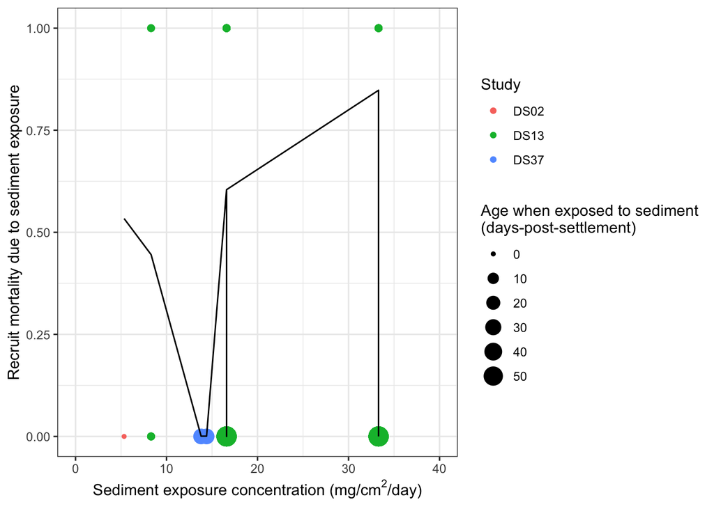

```r
#Overlaying glmm results on figure, but prediction line is jagged...
pred_modDS1 <- predict(modDS1b, newdata=recruitDS2, type="response")
recruitDS3 <- cbind(recruitDS2, pred_modDS1b)

recruitDS_plot <- ggplot(data = recruitDS3) +
    geom_point(mapping = aes(
      x = Sed_level_stand_mg,
      y = Binary_recruit_death,
      color = Ref,
      size = Coral_age_at_start_expt_days_since_settled)) +
    labs(x = expression("Sediment exposure concentration (mg/cm"^"2"*"/day)"),
         y = "Recruit mortality due to sediment exposure",
         color = "Study",
         size = "Age when exposed to sediment\n(days-post-settlement)") +
    scale_x_continuous(limits=c(0,40)) +
    geom_line(aes(x = Sed_level_stand_mg, y = pred_modDS1b), inherit.aes=FALSE) +
    theme_bw()

recruitDS_plot
```

Let’s see if I can plot the average marginal probability, i.e., the average change in probability of the outcome across the range of the predictor of interest. This is described in some detail at the following, useful website: https://stats.idre.ucla.edu/r/dae/mixed-effects-logistic-regression/

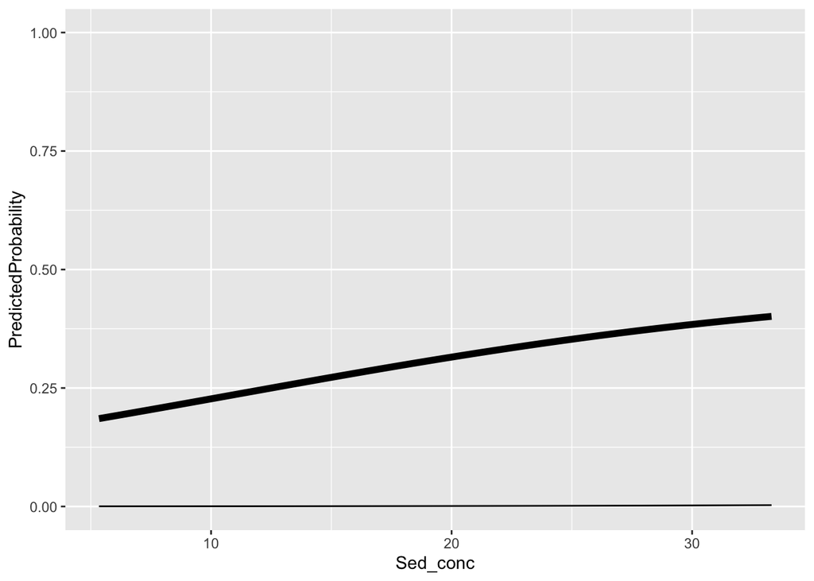

```r
jvalues <- with(recruitDS2, seq(from = min(Sed_level_stand_mg), to = max(Sed_level_stand_mg), length.out = 100))

# calculate predicted probabilities and store in a list
pp <- lapply(jvalues, function(j) {
    recruitDS2$Sed_level_stand_mg <- j
    predict(modDS1b, newdata = recruitDS2, type = "response")
})

# get the means with lower and upper quartiles
plotdat <- t(sapply(pp, function(x) {
    c(M = mean(x), med = median(x), quantile(x, c(0.25, 0.75)))
}))

# add in Sed_level_stand_mg values and convert to data frame
plotdat <- as.data.frame(cbind(plotdat, jvalues))

# better names and show the first few rows
colnames(plotdat) <- c("PredictedProbability", "MedianProbability",
                       "LowerQuantile", "UpperQuantile", "Sed_conc")
#head(plotdat)

# plot average marginal predicted probabilities
ggplot(plotdat, aes(x = Sed_conc)) +
  geom_line(aes(y = PredictedProbability), size = 2) +
  geom_line(aes(y = MedianProbability), size = 0.5) +
  ylim(c(0, 1))
```

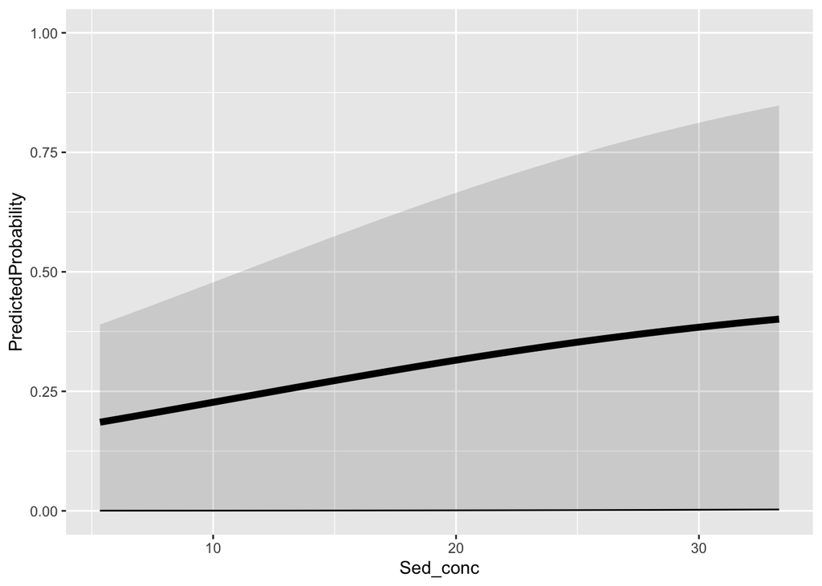

```r
ggplot(plotdat, aes(x = Sed_conc)) +
  geom_ribbon(aes(ymin = LowerQuantile, ymax = UpperQuantile), alpha = 0.15) +
  geom_line(aes(y = PredictedProbability), size = 2) +
  geom_line(aes(y = MedianProbability), size = 0.5) +
  ylim(c(0, 1))
```

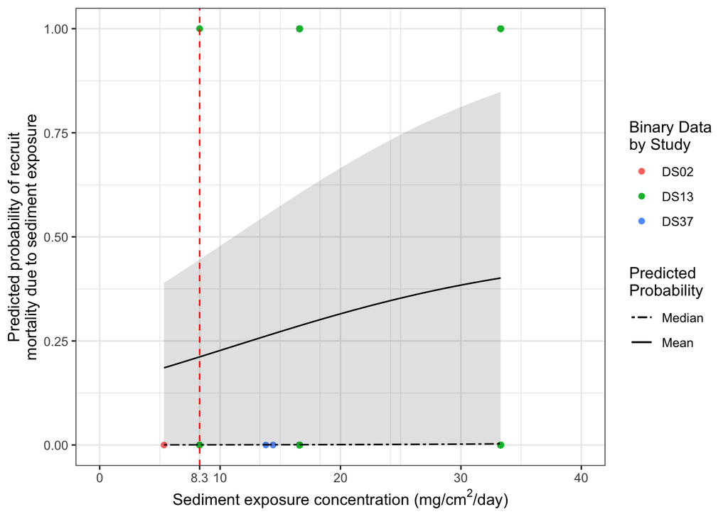

```r
#Overlaying average marginal predicted probabilities on figure
#by Ref
recruitDS_plot3 <- ggplot() +
    geom_point(data = recruitDS2, mapping = aes(
      x = Sed_level_stand_mg,
      y = Binary_recruit_death,
      color = Ref)) +
    labs(x = expression("Sediment exposure concentration (mg/cm"^"2"*"/day)"),
         y = "Predicted probability of recruit\nmortality due to sediment exposure",
         color = "Binary Data\nby Study",
         linetype = "Predicted\nProbability") +
    scale_x_continuous(limits=c(0,40), breaks= c(0,10,20,30,40,loaelDS),
                       labels= c("0","10","20","30","40",round(loaelDS, digits = 1))) +
    geom_ribbon(data = plotdat, aes(x = Sed_conc, y = PredictedProbability,
                                    ymin = LowerQuantile, ymax = UpperQuantile),
                alpha = 0.15) +
    geom_line(data = plotdat, aes(x = Sed_conc, y = PredictedProbability,
                                  linetype = "twodash")) +
    geom_line(data = plotdat, aes(x = Sed_conc, y = MedianProbability,
                                  linetype = "solid")) +
    geom_vline(xintercept=loaelDS, linetype="dashed", color = "red") +
    theme_bw() +
    scale_linetype_manual(values=c("twodash", "solid"), labels = c("Median","Mean"))

recruitDS_plot3
```

## Suspended Sediment

```
##   n
## 1 9
```

```
##         df      AIC
## modSS1b  3 8.919746
## modSS2b  3 8.919746
## modSS3b  3 8.919746
## modSS1   2 7.819085
## modSS2   2 7.819085
## modSS3   2 7.819085
```

```
## boundary (singular) fit: see ?isSingular
```

```
## fixed-effect model matrix is rank deficient so dropping 1 column / coefficient
```

```
## boundary (singular) fit: see ?isSingular
```

```
## fixed-effect model matrix is rank deficient so dropping 2 columns / coefficients
```

```
## boundary (singular) fit: see ?isSingular
```

```
##        df      AIC
## modSS1  2 7.819085
## modSS2  2 7.819085
## modSS3  2 7.819085
## modSS4  3 9.819085
## modSS5  3 9.819085
## modSS6  3 9.819085
```

```
##
## Call:
## glm(formula = Binary_recruit_death ~ Sed_level_stand_mg, family = binomial(link = "logit"),
##     data = recruitSS2)
##
## Deviance Residuals:
##      Min        1Q    Median        3Q       Max
## -0.90052  -0.00008  -0.00008  -0.00001   1.48230
##
## Coefficients:
##                    Estimate Std. Error z value Pr(>|z|)
## (Intercept)         -27.797   9287.765  -0.003    0.998
## Sed_level_stand_mg    0.271     92.878   0.003    0.998
##
## (Dispersion parameter for binomial family taken to be 1)
##
##     Null deviance: 6.2790  on 8  degrees of freedom
## Residual deviance: 3.8191  on 7  degrees of freedom
## AIC: 7.8191
##
## Number of Fisher Scoring iterations: 19
```

### Effect estimates

```
## [1] 0.8888889
```

```
##
## p   0 1
##   0 8 1
```

```
## Area under the curve: 0.875
```

```
##                   R2m       R2c
## theoretical 0.9739595 0.9739595
## delta       0.9239704 0.9239704
```

### Prediction figures

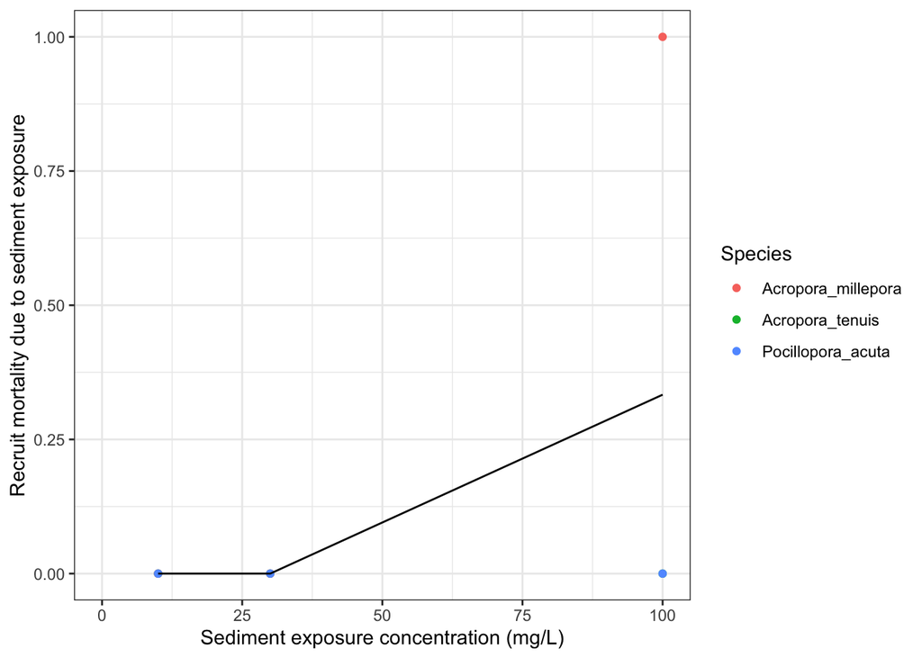

```r
#Overlaying glmm results on figure, but prediction line is jagged...
pred_modSS1 <- predict(modSS1, newdata=recruitSS2, type="response")
recruitSS3 <- cbind(recruitSS2, pred_modSS1)

recruitSS_plot <- ggplot(data = recruitSS3) +
    geom_point(mapping = aes(
      x = Sed_level_stand_mg,
      y = Binary_recruit_death,
      color = Gsp)) +
    labs(x = "Sediment exposure concentration (mg/L)",
         y = "Recruit mortality due to sediment exposure",
         color = "Species") +
    scale_x_continuous(limits=c(0,100)) +
    geom_line(aes(x = Sed_level_stand_mg, y = pred_modSS1), inherit.aes=FALSE) +
    theme_bw()

recruitSS_plot
```

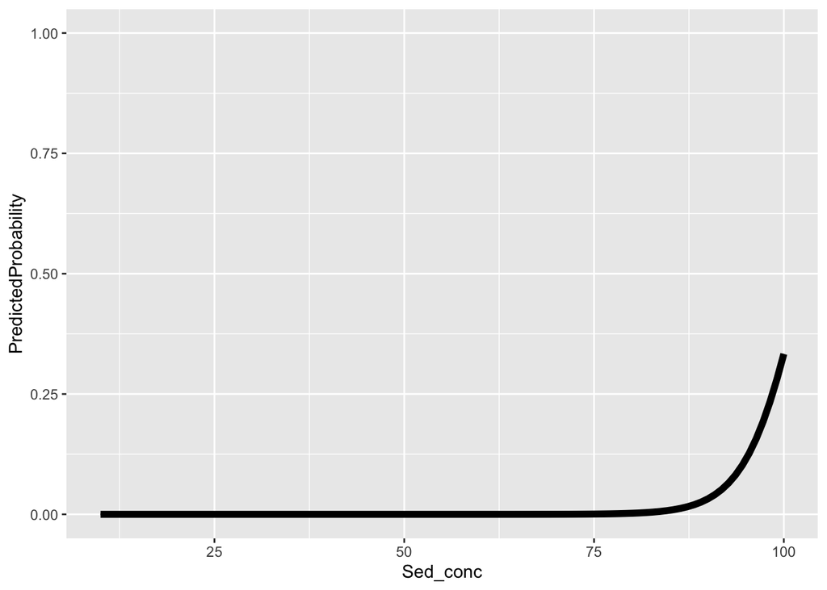

```r
jvalues <- with(recruitSS2, seq(from = min(Sed_level_stand_mg), to = max(Sed_level_stand_mg), length.out = 100))

# calculate predicted probabilities and store in a list
pp <- lapply(jvalues, function(j) {
    recruitSS2$Sed_level_stand_mg <- j
    predict(modSS1, newdata = recruitSS2, type = "response")
})

# get the means with lower and upper quartiles
plotdat <- t(sapply(pp, function(x) {
    c(M = mean(x), med = median(x), quantile(x, c(0.25, 0.75)))
}))

# add in Sed_level_stand_mg values and convert to data frame
plotdat <- as.data.frame(cbind(plotdat, jvalues))

# better names and show the first few rows
colnames(plotdat) <- c("PredictedProbability", "MedianProbability",
                       "LowerQuantile", "UpperQuantile", "Sed_conc")
#head(plotdat)

# plot average marginal predicted probabilities
ggplot(plotdat, aes(x = Sed_conc)) +
  geom_line(aes(y = PredictedProbability), size = 2) +
  geom_line(aes(y = MedianProbability), size = 0.5) +
  ylim(c(0, 1))
```

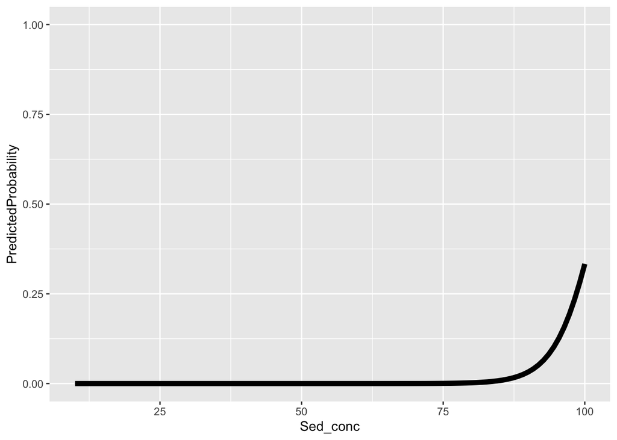

```r
ggplot(plotdat, aes(x = Sed_conc)) +
  geom_ribbon(aes(ymin = LowerQuantile, ymax = UpperQuantile), alpha = 0.15) +
  geom_line(aes(y = PredictedProbability), size = 2) +
  geom_line(aes(y = MedianProbability), size = 0.5) +
  ylim(c(0, 1))
```

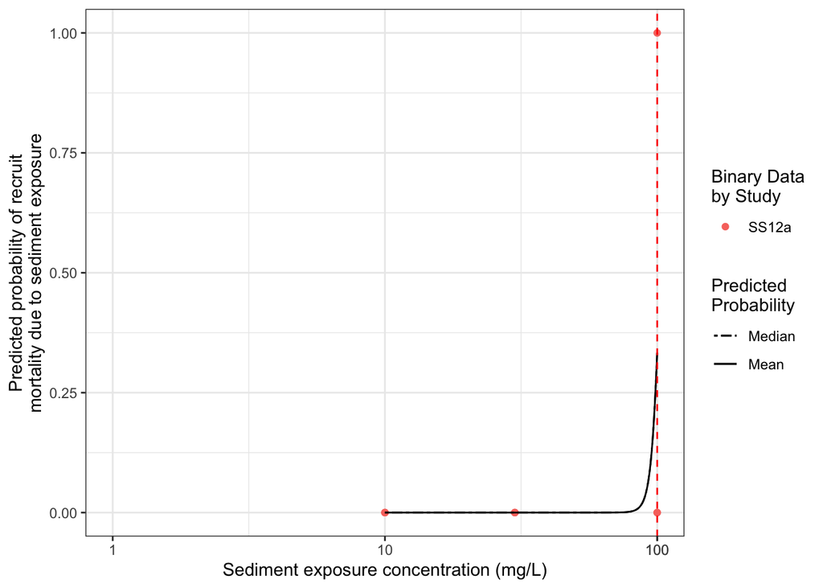

```r
#Overlaying average marginal predicted probabilities on figure
#by Ref
recruitSS_plot2 <- ggplot() +
    geom_point(data = recruitSS2, mapping = aes(
      x = Sed_level_stand_mg,
      y = Binary_recruit_death,
      color = Ref)) +
    labs(x = "Sediment exposure concentration (mg/L)",
         y = "Predicted probability of recruit\nmortality due to sediment exposure",
         color = "Binary Data\nby Study",
         linetype = "Predicted\nProbability") +
    scale_x_log10(limits=c(1,max(recruitSS2$Sed_level_stand_mg)),
                  breaks=c(0.01,0.1,1,10,100,1000,loaelSS),
                  label=c("0.01","0.1","1","10","100","1000",round(loaelSS,digits=1))) +
    geom_ribbon(data = plotdat, aes(x = Sed_conc, y = PredictedProbability,
                                    ymin = LowerQuantile, ymax = UpperQuantile),
                alpha = 0.15) +
    geom_line(data = plotdat, aes(x = Sed_conc, y = PredictedProbability,
                                  linetype = "twodash")) +
    geom_line(data = plotdat, aes(x = Sed_conc, y = MedianProbability,
                                  linetype = "solid")) +
    geom_vline(xintercept=loaelSS, linetype="dashed", color = "red") +
    theme_bw() +
    scale_linetype_manual(values=c("twodash", "solid"), labels = c("Median","Mean"))

recruitSS_plot2
```